# RepData_PeerAssignment1

Nick Hitt

11/14/2020

## Loading and preprocessing the data

```r
if(!file.exists(dir)){
  unzip("Activity.zip", files = NULL, exdir=".")
}

activity <- read.csv("activity.csv")
```

We need to remove the zeros from steps because the zeros bias the median calculation

```r
steps_zer_removed <- activity[which(activity$steps != 0),] # removing zeros from steps because the zeros bias the median calculation
```

## What is mean total number of steps taken per day?

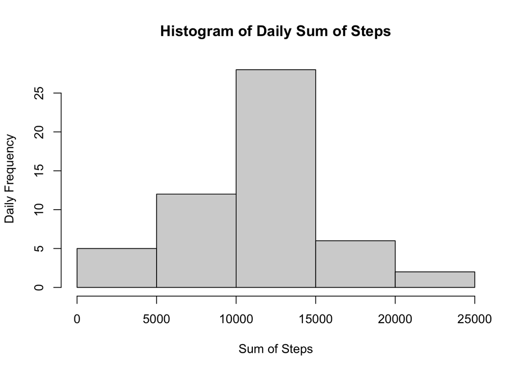

```r
daily_avg_steps <- aggregate(steps ~ date, activity, mean, na.rm = TRUE)

med_steps <- aggregate(as.numeric(steps) ~ date, steps_zer_removed, median, na.rm = TRUE)

sum_steps <- aggregate(steps ~ date, activity, sum, na.rm = TRUE)

hist(sum_steps[,2], main = "Histogram of Daily Sum of Steps",
     xlab = "Sum of Steps", ylab = "Daily Frequency", xaxt = "n")
axis(side=1, at=(seq(0,25000,5000)), labels=seq(0,25000,5000))
```

```r
sum_steps
```

```
##          date steps
## 1  2012-10-02   126
## 2  2012-10-03 11352
## 3  2012-10-04 12116
## 4  2012-10-05 13294
## 5  2012-10-06 15420
## 6  2012-10-07 11015
## 7  2012-10-09 12811
## 8  2012-10-10  9900
## 9  2012-10-11 10304
## 10 2012-10-12 17382
## 11 2012-10-13 12426
## 12 2012-10-14 15098
## 13 2012-10-15 10139
## 14 2012-10-16 15084
```

[output cut: 39 more lines]

## What is the average daily activity pattern?

Here we need to find the average amount of steps per time interval of the day

```r
int_avg_steps <- aggregate(steps ~ interval, activity, mean, na.rm = TRUE)
```

```r
max_steps <- max(int_avg_steps[,2])
int_max_steps <- int_avg_steps[which(int_avg_steps[,2] == max_steps),1]
```

Then plot the data

[figure not shown]

```r
library(ggplot2)
g <- ggplot(int_avg_steps,aes(interval,steps))

p<- g + geom_point() +geom_line() + ggtitle(expression("Total Steps by Interval")) +
  ylab(expression("Total Steps")) +
  xlab("Interval")

print(p)
```

[figure not shown]

```r
show(p)
```

## Imputing missing values

Now we need to ‘fix’ the data by replacing the missing values with data. We will do this by running a for loop that checks if each data point is missing or not. If it is missing then we will replace it with the average steps in that interval

```r
activity_na <- is.na(activity$steps)
total_na <- sum(activity_na)


fillNA <- numeric()
for (i in 1:nrow(activity)) {
  obs <- activity[i, ]
  if (is.na(obs$steps)) {
    steps <- subset(int_avg_steps, interval == obs$interval)$steps
  } else {
    steps <- obs$steps
  }
  fillNA <- c(fillNA, steps)
}
```

Now we should check and see how that effected the data. We will do that by making a histogram of thew daily sum of steps

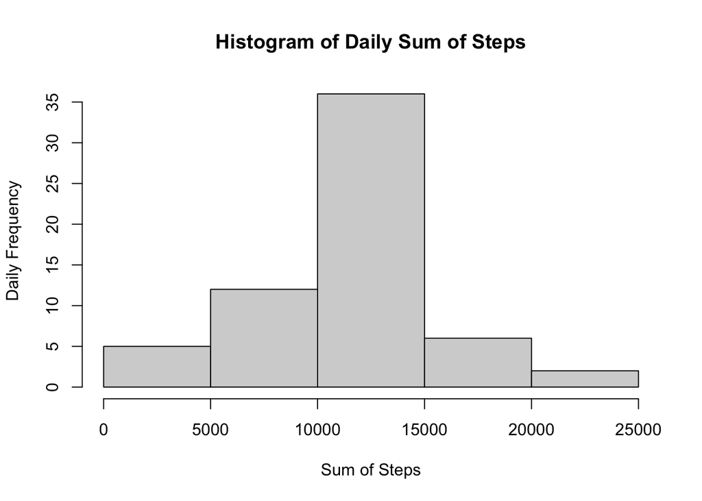

```r
new_activity <- activity
new_activity$steps <- fillNA

new_steps_zer_removed <- new_activity[which(new_activity$steps != 0),]

new_daily_avg_steps <- aggregate(steps ~ date, new_activity, mean, na.rm = TRUE)
new_sum_steps <- aggregate(steps ~ date, new_activity, sum, na.rm = TRUE)
new_med_steps <- aggregate(steps ~ date, new_activity, median, na.rm = TRUE)


hist(new_sum_steps[,2], main = "Histogram of Daily Sum of Steps",
     xlab = "Sum of Steps", ylab = "Daily Frequency", xaxt = "n")
axis(side=1, at=(seq(0,25000,5000)), labels=seq(0,25000,5000))
```

## Are there differences in activity patterns between weekdays and weekends?

Now we should check and see if there are differences between activity patterns between the weekend and week days. We will change the dates to weekdays/weekends and then use those to plot a panel plot of the data to compare

[figure not shown]

```r
new_activity$date <- as.Date(new_activity$date)
days <- c(1:nrow(new_activity))

factor_days <- c(1:nrow(new_activity))
days <- weekdays(new_activity$date)

days <- factor(days, levels = c("Monday", "Tuesday" , "Wednesday", "Thursday", "Friday","Saturday", "Sunday"),
             labels = c("Weekday","Weekday","Weekday","Weekday","Weekday","Weekend","Weekend"))

days <- data.frame("days" = days)

new_activity <- cbind(new_activity, days)

day_steps <- aggregate(steps ~ interval + days, new_activity, mean, na.rm = TRUE)

g1 <- ggplot(data = new_activity, aes(steps, interval)) +
  geom_line(color = "steelblue", size = 1) +
  labs(y = "Number of Steps", x = "Interval") +
  facet_grid(days ~.)

print(g1)
```